# Preliminary steps to classification

SDL - Progetto Audizioni

L’obiettivo di questa parte del progetto è di classificare gli stakeholders che hanno preso parte alle audizioni informali del Senato, sulla scia delle categorie utilizzate da The Good Lobby nella mappatura della Camera.

La classificazione di The Good Lobby prende spunto dalla tassonomia sviluppata dal (ex) Ministero dello Sviluppo Economico (MISE) nel Registro Trasparenza, uno strumento di autocertificazione per gli interlocutori del Ministero in nome della trasparenza e dell’accountability.

Il report presenta i dataset a disposizione, con un’analisi esplorativa delle categorie e delle entità da classificare.

```r
library(readxl)
library(tidyverse)
library(ggplot2)
library(forcats)
library(scales)
library(stringr)
```

## Camera - The Good Lobby

Ciascuna riga del dataset rappresenta una singola audizione; le colonne ne descrivono i dettagli.

Sono state registrate 7 informazioni su 4559 audizioni:

1. Commissione: la/le commissione/i parlamentari coinvolte;
2. Data: la data dell’audizione;
3. Proposta di Legge: l’oggetto dell’audizione;

Le informazioni sugli stakeholders auditi sono specificate su due variabili distinte:

4. Nome e cognome: della persona audita;
5. Ente/Organizzazione: di cui l’audito fa le veci;

Può accadere di trovare entrambe le informazioni, o solo una delle due.

Infine, due variabili di classificazione:

6. Tipologia soggetto: tipizzazione degli stakeholders in categorie;
7. Materia: tipizzazione delle “Proposte di legge” per ambito di intervento.

Le variabili che contengono informazioni sugli stakeholders sono tre: “Nome e cognome”, “Ente/organizzazione”, “Tipologia soggetto”.

Vediamo qualche statistica.

```r
camera <- read_excel("C:/Users/SImone/Desktop/standardization/Dataset/Mappatura audizioni informali Camera (definitiva e con PNRR).xlsx")

camera <- select(camera, -c(8:12))
camera <- camera[-1, ]

camera$`Ente/Organizzazione` <- str_to_upper(camera$`Ente/Organizzazione`)
camera$`Nome e cognome` <- str_to_upper(camera$`Nome e cognome`)

camera <- unique(camera)

glimpse(camera)
```

```
## Rows: 4,559
## Columns: 7
## $ Commissione           <chr> "Commissioni riunite Camera e Senato (II-VI-XIV …
## $ Data                  <dttm> 2019-09-18, 2019-09-17, 2019-09-17, 2019-09-17,…
## $ `Ente/Organizzazione` <chr> "UNITÀ DI INFORMAZIONE FINANZIARIA PER L'ITALIA …
## $ `Tipologia soggetto`  <chr> "Autorità indipendenti/soggetti istituzionali", …
## $ `Nome e cognome`      <chr> NA, "FEDERICO CAFIERO DE RAHO ( PROCURATORE NAZI…
## $ `Proposta di Legge`   <chr> "Decreti legislativi 25 maggio 2017, n. 90 e n. …
## $ Materia               <chr> "Prevenzione dell'uso del sistema finanziario a …
```

```r
camera$`Tipologia soggetto` <- ifelse(camera$`Tipologia soggetto`=="Aziende a partecipazione pubblica", "Aziende e società a partecipazione pubblica",
                                    ifelse(camera$`Tipologia soggetto`=="Sindacati e associazioni di categorie", "Sindacati e associazioni di categoria",
                                           camera$`Tipologia soggetto`))

table(camera$`Tipologia soggetto`)
```

```
##
##                                              Altro
##                                                195
## Associazioni e organizzazioni della società civile
##                                                479
##       Autorità indipendenti/soggetti istituzionali
##                                               1131
##                                            Aziende
##                                                111
##        Aziende e società a partecipazione pubblica
##                                                 99
##     professori universitari/esperti/professionisti
##                                                810
##              Sindacati e associazioni di categoria
##                                               1734
```

### Percentage by group - Audizioni by categories

Il prossimo grafico, mostra la proporzione delle audizioni per categoria. Possiamo farci un’idea sugli interessi più o meno ascoltati.

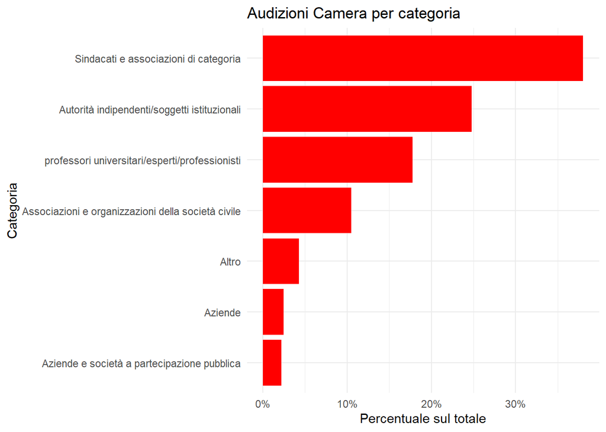

```r
prop_lab <- camera %>%
  group_by(`Tipologia soggetto`) %>%
  summarize(prop = n()/nrow(camera) * 100)

ggplot(prop_lab, aes(x = fct_reorder(`Tipologia soggetto`, prop), y = prop)) +
  geom_bar(stat = "identity", fill = "red") +
  scale_y_continuous(labels=scales::percent_format(scale = 1)) +
  labs(title = 'Audizioni Camera per categoria', x = 'Categoria', y = 'Percentuale sul totale') +
  coord_flip() +
  theme_minimal()
```

### Bar graph of counts - Entities by categories

Questo grafico mostra la conta delle entità classificate in ciascuna categoria.

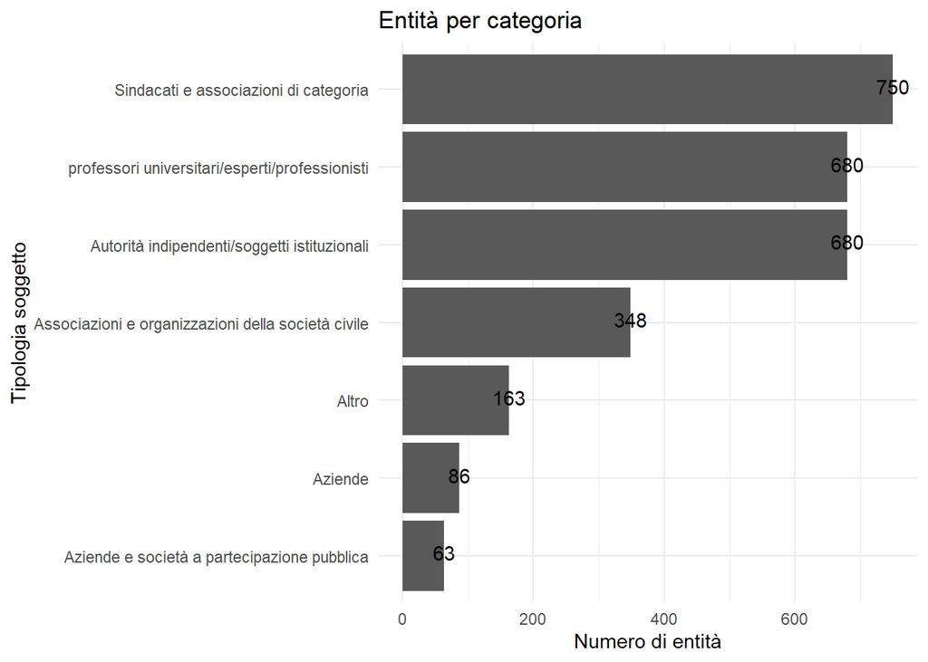

```r
categ_camera <- camera %>% select(`Ente/Organizzazione`, `Nome e cognome`, `Tipologia soggetto`) %>% unique()

categ_camera %>% group_by(`Tipologia soggetto`) %>% summarise(count = n()) %>%
  arrange(count) %>%
  mutate(`Tipologia soggetto` = factor(`Tipologia soggetto`, levels = `Tipologia soggetto`)) %>%
  ggplot(aes(`Tipologia soggetto`, count)) +
  geom_col() +
  coord_flip() +
  geom_text(aes(label = count), vjust = 0.3) +
  labs(title = "Entità per categoria", y = "Numero di entità") +
  theme_minimal()
```

### Criticità riscontrate

Si consideri il margine di errore: nel dataset ci sono mispelling (entità codificate non in modo univoco), entità registrate in modo indefinito (ad esempio, sotto la dicitura “esperti”, si ipotizza quando l’informazione manchi), ed entità classificate in più categorie.

Ad esempio, esploriamo la categoria “professori universitari/esperti/professionisti”.

- Entità mancanti sotto la dicitura “esperti” in “Enti/organizzazioni”

```r
cat_esperti <- camera %>% filter(`Tipologia soggetto`=="professori universitari/esperti/professionisti")

cat_esperti[!is.na(cat_esperti$`Ente/Organizzazione`), ]
```

```
## # A tibble: 6 × 7
##   Commissione     Data                `Ente/Organizzazione` `Tipologia soggetto`
##   <chr>           <dttm>              <chr>                 <chr>
## 1 I Affari Costi… 2019-07-04 00:00:00 UNHCR (ALTO COMMISSA… professori universi…
## 2 I Affari Costi… 2018-07-18 00:00:00 ESPERTI DELLA MATERIA professori universi…
## 3 III Affari Est… 2020-03-04 00:00:00 GRUPPO DI ESPERTI     professori universi…
## 4 XII Affari Soc… 2020-02-18 00:00:00 ESPERTI DELLA MATERIA professori universi…
## 5 XII Affari Soc… 2020-01-14 00:00:00 ESPERTI DELLA MATERIA professori universi…
## 6 XII Affari Soc… 2020-02-19 00:00:00 ESPERTI DELLA MATERIA professori universi…
## # ℹ 3 more variables: `Nome e cognome` <chr>, `Proposta di Legge` <chr>,
## #   Materia <chr>
```

- Entità mancanti sotto la dicitura “esperti” in “Nome e cognome”

```r
cat_esperti[grep("ESPERTI", cat_esperti$`Nome e cognome`), ]
```

```
## # A tibble: 19 × 7
##    Commissione    Data                `Ente/Organizzazione` `Tipologia soggetto`
##    <chr>          <dttm>              <chr>                 <chr>
##  1 Commissioni r… 2019-01-24 00:00:00 <NA>                  professori universi…
##  2 I Affari Cost… 2018-07-18 00:00:00 <NA>                  professori universi…
##  3 IV Difesa      2020-10-01 00:00:00 <NA>                  professori universi…
##  4 IV Difesa      2020-09-23 00:00:00 <NA>                  professori universi…
##  5 IV Difesa      2020-09-09 00:00:00 <NA>                  professori universi…
##  6 IX Trasporti,… 2020-12-14 00:00:00 <NA>                  professori universi…
##  7 IX Trasporti,… 2020-07-07 00:00:00 <NA>                  professori universi…
##  8 IX Trasporti,… 2020-06-30 00:00:00 <NA>                  professori universi…
##  9 IX Trasporti,… 2019-03-06 00:00:00 <NA>                  professori universi…
## 10 IX Trasporti,… 2020-12-16 00:00:00 <NA>                  professori universi…
## 11 IX Trasporti,… 2019-10-08 00:00:00 <NA>                  professori universi…
## 12 VI Finanze     2019-11-05 00:00:00 <NA>                  professori universi…
## 13 VI Finanze e … 2018-07-19 00:00:00 <NA>                  professori universi…
## 14 VI Finanze e … 2018-07-19 00:00:00 <NA>                  professori universi…
## 15 VII Cultura, … 2019-07-24 00:00:00 <NA>                  professori universi…
## 16 VII Cultura, … 2020-06-09 00:00:00 <NA>                  professori universi…
## 17 XI Lavoro pub… 2018-10-10 00:00:00 <NA>                  professori universi…
## 18 XIV Politiche… 2020-07-30 00:00:00 <NA>                  professori universi…
## 19 XIV Politiche… 2020-07-30 00:00:00 <NA>                  professori universi…
## # ℹ 3 more variables: `Nome e cognome` <chr>, `Proposta di Legge` <chr>,
## #   Materia <chr>
```

- Entità classificate in più di una categoria: mis-categorizzazioni in “Enti/organizzazioni”

```r
ente_miscat <- camera %>% select(`Ente/Organizzazione`, `Tipologia soggetto`) %>% subset(!is.na(`Ente/Organizzazione`)) %>% unique()
enti_camera <- unique(ente_miscat$`Ente/Organizzazione`)
ente_miscat <- ente_miscat %>% group_by(`Ente/Organizzazione`) %>% mutate(times = n()) %>% subset(times > 1)
ente_miscat <- ente_miscat[order(ente_miscat$`Ente/Organizzazione`), ] %>% print(n = Inf)
```

```
## # A tibble: 24 × 3
## # Groups:   Ente/Organizzazione [12]
##    `Ente/Organizzazione`                              `Tipologia soggetto` times
##    <chr>                                              <chr>                <int>
##  1 ASSOCIAZIONE LIBERA                                Associazioni e orga…     2
##  2 ASSOCIAZIONE LIBERA                                Aziende e società a…     2
##  3 ASSOCIAZIONE NAZIONALE DEI PICCOLI COMUNI D'ITALI… Sindacati e associa…     2
##  4 ASSOCIAZIONE NAZIONALE DEI PICCOLI COMUNI D'ITALI… Altro                    2
##  5 CNF (CONSIGLIO NAZIONALE FORENSE)                  Autorità indipenden…     2
##  6 CNF (CONSIGLIO NAZIONALE FORENSE)                  Sindacati e associa…     2
##  7 FEDERAZIONE ITALIANA PESCA SPORTIVA E ATTIVITÀ SU… Sindacati e associa…     2
##  8 FEDERAZIONE ITALIANA PESCA SPORTIVA E ATTIVITÀ SU… Altro                    2
##  9 FEDERDISTRIBUZIONE                                 Autorità indipenden…     2
## 10 FEDERDISTRIBUZIONE                                 Sindacati e associa…     2
## 11 FIPSAS (FED. IT. PESCA SPORTIVA E ATTIVITÀ SUBACQ… Altro                    2
## 12 FIPSAS (FED. IT. PESCA SPORTIVA E ATTIVITÀ SUBACQ… Sindacati e associa…     2
## 13 MOVIMENTO DIFESA GAE                               Sindacati e associa…     2
## 14 MOVIMENTO DIFESA GAE                               Associazioni e orga…     2
## 15 NUOVO IMAIE                                        Altro                    2
## 16 NUOVO IMAIE                                        Associazioni e orga…     2
## 17 SIN (SISTEMA INFORMATIVO NAZIONALE) SPA            Autorità indipenden…     2
## 18 SIN (SISTEMA INFORMATIVO NAZIONALE) SPA            Aziende e società a…     2
## 19 SOS MUSICISTI                                      Associazioni e orga…     2
## 20 SOS MUSICISTI                                      Sindacati e associa…     2
## 21 TURISMO VERDE                                      Associazioni e orga…     2
## 22 TURISMO VERDE                                      Sindacati e associa…     2
## 23 UNHCR (ALTO COMMISSARIATO NAZIONI UNITE PER I RIF… Autorità indipenden…     2
## 24 UNHCR (ALTO COMMISSARIATO NAZIONI UNITE PER I RIF… professori universi…     2
```

- Entità classificate in più di una categoria: mis-categorizzazioni in “Nome e cognome”

```r
sogg_miscat <- camera %>% select(`Nome e cognome`, `Tipologia soggetto`) %>% subset(!is.na(`Nome e cognome`)) %>% unique()
sogg_camera <- unique(sogg_miscat$`Nome e cognome`)
sogg_miscat <- sogg_miscat %>% group_by(`Nome e cognome`) %>% mutate(times = n()) %>% subset(times > 1)
sogg_miscat <- sogg_miscat[order(sogg_miscat$`Nome e cognome`), ] %>% print(n = Inf)
```

```
## # A tibble: 30 × 3
## # Groups:   Nome e cognome [15]
##    `Nome e cognome`                                   `Tipologia soggetto` times
##    <chr>                                              <chr>                <int>
##  1 FEDERICO CAFIERO DE RAHO (PROCURATORE NAZIONALE A… professori universi…     2
##  2 FEDERICO CAFIERO DE RAHO (PROCURATORE NAZIONALE A… Autorità indipenden…     2
##  3 FRANCESCO BASENTINI, CAPO DEL DIPARTIMENTO DELL'A… professori universi…     2
##  4 FRANCESCO BASENTINI, CAPO DEL DIPARTIMENTO DELL'A… Autorità indipenden…     2
##  5 GABRIELE PAPA PAGLIARDINI                          Autorità indipenden…     2
##  6 GABRIELE PAPA PAGLIARDINI                          professori universi…     2
##  7 GABRIELLA PALMIERI, AVVOCATO GENERALE DELLO STATO  professori universi…     2
##  8 GABRIELLA PALMIERI, AVVOCATO GENERALE DELLO STATO  Autorità indipenden…     2
##  9 GEN. S. A. CARLO MAGRASSI, SEGRETARIO GENERALE DE… Autorità indipenden…     2
## 10 GEN. S. A. CARLO MAGRASSI, SEGRETARIO GENERALE DE… professori universi…     2
## 11 GIAN PIERO SCANU, PRESIDENTE DELLA COMMISSIONE PA… professori universi…     2
```

[output cut: 19 more lines]

## Registro Trasparenza - MISE, Ministero dello Sviluppo Economico

Il dataset contiene informazioni autocertificate dalle stesse entità spalmate in 26 variabili.

Per il nostro scopo di classificazione, le variabili “Iscrizione.ad.associazioni” e “Associazioni.Iscritte” (non presente nel dataset ma salvata in locale per ragioni di dimensione) possono essere la base per una network analysis che descriva l’ecosistema degli stakeholders.

```r
mise <- read_excel("C:/Users/SImone/Desktop/standardization/Dataset/mise.xlsx")

mise$Nome <- str_to_upper(mise$Nome)
mise <- mise[!is.na(mise$Nome), ] %>% unique()

glimpse(mise)
```

```
## Rows: 2,277
## Columns: 26
## $ Nome                       <chr> "ASSOCIAZIONE NAZIONALE ENERGIA DEL VENTO",…
## $ Acronimo                   <chr> "ANEV", "Fegica Cisl", NA, "ANITA", NA, "CO…
## $ Forma.Giuridica            <chr> "Altro: Associazione senza fini di lucro", …
## $ Sito.Internet              <chr> "\r\n\t\t\t\t\r\n\t\t\t\t\t\r\n\t\t\t\t\t\t…
## $ Categoria                  <chr> "Imprese e associazioni di categoria, comme…
## $ Sottocategoria             <chr> "Associazioni commerciali e di categoria", …
## $ Responsabile.Legale        <chr> "\r\n\t\t\t\t\t\tSimone, Togni", "\r\n\t\t\…
## $ Qualifica                  <chr> "Presidente", "Presidente", "AD", "Presiden…
## $ Mission                    <chr> "\r\n\t\t\t\t\t\tANEV - Associazione Nazion…
## $ Posizionamento             <chr> "europeomondialenazionaleregionale\t\t\t\t\…
## $ Policy.Seguite             <chr> "\r\n\t\t\t\t\t\tDefinizione della normativ…
## $ Policy.Proposte            <chr> "\r\n\t\t\t\t\t\tSostegno allo sviluppo del…
## $ Gruppi.Lavoro              <chr> "\r\n\t\t\t\t\t\tSì", "\r\n\t\t\t\t\t\tNo",…
## $ Comitati.Consultivi        <chr> "\r\n\t\t\t\t\t\tSì", "\r\n\t\t\t\t\t\tNo",…
## $ Info.Partecipazione        <chr> "\r\n\t\t\t\t\t\tSiamo chiamati nelle consu…
## $ Persone.Coinvolte          <chr> "\r\n\t\t\t\t\t\t2", "\r\n", "\r\n\t\t\t\t\…
## $ Info.Persone               <chr> "\r\n", "\r\n", "\r\n", "\r\n", "\r\n", "\r…
## $ Settori.di.Interesse       <chr> "PetrolioGas NaturaleEnergia ElettricaFonti…
## $ Iscrizione.ad.Associazioni <chr> "\r\n\t\t\t\t\t  Confindustria Energia-Coor…
## $ Anno.Esercizio             <chr> "\r\n\t\t\t\t\t\t01/12/2014\t\t\t\t\t\t - \…
## $ Costi                      <chr> "\r\n\t\t\t\t\t0  €", "\r\n\t\t\t\t\t< 9.99…
## $ Appalti                    <chr> "\r\n\t\t\t\t\t\t0  €", "\r\n\t\t\t\t\t\t0 …
## $ Sovvenzioni                <chr> "\r\n\t\t\t\t\t\t0  €", "\r\n\t\t\t\t\t\t0 …
## $ Contributi                 <chr> "\r\n\t\t\t\t\t\t0  €", "\r\n\t\t\t\t\t\t0 …
## $ Fatturato                  <chr> "\r\n\t\t\t\t\t  €", "\r\n\t\t\t\t\t  €", "…
## $ Info.Finanziarie           <chr> "\r\n\t\t\t\t\t\tL'ANEV ha come unica fonte…
```

Esploriamo le categorie e sottocategorie utilizzate in ambito istituzionale per classificare le entità, dalle quali The Good Lobby ha preso ispirazione.

```r
table(mise$Categoria)
```

```
##
##                                                               Centri di studio, istituti accademici e di ricerca
##                                                                                                               79
##                                                Imprese e associazioni di categoria, commerciali e professionisti
##                                                                                                             1547
##                                                                                   Organizzazioni non governative
##                                                                                                              125
## Organizzazioni rappresentative di amministrazioni locali, regionali e comunali, altri enti pubblici o misti ecc.
##                                                                                                               58
##                                                    Organizzazioni rappresentative di chiese e comunità religiose
##                                                                                                                1
##                                         Società di consulenza specializzate/studi legali/consulenti indipendenti
##                                                                                                              467
```

```r
table(mise$Sottocategoria)
```

```
##
##                                                                         Altre autorità pubbliche subnazionali
##                                                                                                             3
##                                                                                          Altre organizzazioni
##                                                                                                           115
##                                                                       Associazioni commerciali e di categoria
##                                                                                                           385
## Associazioni e reti transnazionali di autorità pubbliche regionali o di altre autorità pubbliche subnazionali
##                                                                                                            15
##                                                                        Centri di studio e istituti di ricerca
##                                                                                                            58
##                                                                                       Consulenti indipendenti
##                                                                                                           176
##                                                                                              Imprese e gruppi
##                                                                                                           893
##                                                                                           Istituti accademici
##                                                                                                            21
##                                                   Organizzazioni non governative, piattaforme e reti e simili
##                                                                                                           125
##                                                 Organizzazioni rappresentative di chiese e comunità religiose
##                                                                                                             1
##                                                                        Sindacati e associazioni professionali
##                                                                                                           154
##                                                                           Società di consulenza specializzate
##                                                                                                           225
##                                                                                           Strutture regionali
##                                                                                                            40
##                                                                                                  Studi legali
##                                                                                                            66
```

### Criticità riscontrate

Ci sono 2080 entità uniche registrate ma alcune si sono autoclassificate in categorie o sottocategorie differenti in momenti diversi.

```r
categ_mise <- mise %>% select(Nome, Categoria, Sottocategoria) %>% unique()

enti <- categ_mise$Nome %>% unique()

mise_miscat <- categ_mise %>% group_by(Nome) %>% mutate(times = n()) %>% subset(times > 1)
mise_miscat <- mise_miscat[order(mise_miscat$Nome), ] %>% print(n = Inf)
```

```
## # A tibble: 54 × 4
## # Groups:   Nome [27]
##    Nome                                           Categoria Sottocategoria times
##    <chr>                                          <chr>     <chr>          <int>
##  1 "\"SOCIETÀ JURIBIT S.R.L.\""                   Società … Società di co…     2
##  2 "\"SOCIETÀ JURIBIT S.R.L.\""                   Centri d… Centri di stu…     2
##  3 "A.T.& F. OFFICE INNOVATION SRL"               Società … Consulenti in…     2
##  4 "A.T.& F. OFFICE INNOVATION SRL"               Imprese … Imprese e gru…     2
##  5 "ASSICUREZZA"                                  Imprese … Sindacati e a…     2
##  6 "ASSICUREZZA"                                  Imprese … Associazioni …     2
##  7 "ASSOCIAZIONE DEGLI ENTI PREVIDENZIALI PRIVAT… Imprese … Altre organiz…     2
##  8 "ASSOCIAZIONE DEGLI ENTI PREVIDENZIALI PRIVAT… Imprese … Sindacati e a…     2
##  9 "ASSOCIAZIONE DELLE CAMERE DI COMMERCIO ITALI… Imprese … Associazioni …     2
## 10 "ASSOCIAZIONE DELLE CAMERE DI COMMERCIO ITALI… Organizz… Associazioni …     2
## 11 "ASSOCIAZIONE ITALIANA WEDDING PLANNER"        Imprese … Associazioni …     2
```

[output cut: 43 more lines]

## Senato - Progetto Audizioni

Il dataset del Senato è stato costruito prendendo come modello quello della Camera. Ogni riga rappresenta un’audizione; le colonne ne descrivono i dettagli.

Sono state raccolte 4 informazioni su 7084 audizioni:

1. Commissione: la/le commissione/i parlamentari coinvolte;
2. Data: la data dell’audizione;
3. Atto: l’oggetto dell’audizione;
4. Nomi: il soggetto audito.

A differenza dei dati sulla Camera, qui le informazioni sugli stakeholders sono contenute in una sola variabile, “Nomi”.

Si contano 4276 singole entità ma le criticità non mancano: ci sono mispelling.

```r
senato <- read_excel("C:/Users/SImone/Desktop/audizioni_informali/data/preprocessed_data/dataset_senato.xlsx")

senato$NOMI <- str_to_upper(senato$NOMI)
senato <- unique(senato)

nomi_senato <- unique(senato$NOMI)

glimpse(senato)
```

```
## Rows: 7,084
## Columns: 4
## $ COMMISSIONE <chr> "1 (Aff. costituzionali)", "1 (Aff. costituzionali)", "1 (…
## $ NOMI        <chr> "PROF.SSA DI PORTO", "PROF. DI MARTIN", "PROF. CELOTTO", "…
## $ ATTO        <chr> "Audizioni informali sull'affare assegnato n. 1144 (Metave…
## $ DATA        <chr> "2022-07-14", "2022-07-14", "2022-07-06", "2022-05-26", "2…
```

## Test di corrispondenza delle nomenclature tra i dataset

Si può ipotizzare che alcuni stakeholders siano interlocutori di più realtà istituzionali e dunque che qualche elemento del Senato da classificare sia presente e già catalogato negli altri due dataset.

Partendo dalle corrispondenze esatte di nomenclatura delle entità, si può approcciare una prima classificazione degli elementi in comune.

```r
df_nomi_senato <- as.data.frame(nomi_senato)
df_enti_mise <- mise %>% select(Nome, Categoria) %>% subset(!is.na(Nome)) %>% unique()

senato_mise <- inner_join(df_nomi_senato, df_enti_mise, by=c("nomi_senato"="Nome")) #90

df_enti_camera <- camera %>% select(`Ente/Organizzazione`, `Tipologia soggetto`) %>% subset(!is.na(`Ente/Organizzazione`)) %>% unique()
senato_enti_camera <- inner_join(df_nomi_senato, df_enti_camera, by=c("nomi_senato"="Ente/Organizzazione")) #340

df_sogg_camera <- camera %>% select(`Nome e cognome`, `Tipologia soggetto`) %>% subset(!is.na(`Nome e cognome`)) %>% unique()
senato_sogg_camera <- inner_join(df_nomi_senato, df_sogg_camera, by=c("nomi_senato"="Nome e cognome")) #8

senato_camera <- rbind(senato_enti_camera, senato_sogg_camera)

matches <- full_join(senato_mise, senato_camera, by = "nomi_senato")
names(matches) <- c("ENTITY", "LABEL_MISE", "LABEL_TGL")

matches <- matches[order(matches$ENTITY),]
matches <- as_tibble(matches)
print(matches, n = Inf)
```

```
## # A tibble: 412 × 3
##     ENTITY                                                  LABEL_MISE LABEL_TGL
##     <chr>                                                   <chr>      <chr>
##   1 A2A                                                     Imprese e… <NA>
##   2 ACQUIRENTE UNICO                                        <NA>       Aziende …
##   3 ADICONSUM                                               <NA>       Associaz…
##   4 AERANTI-CORALLO                                         Imprese e… <NA>
##   5 AERO CLUB D'ITALIA                                      <NA>       Autorità…
##   6 AEROPORTI DI ROMA S.P.A.                                Imprese e… <NA>
##   7 AGENZIA DEL DEMANIO                                     <NA>       Autorità…
##   8 AGENZIA DELLE DOGANE E DEI MONOPOLI                     <NA>       Autorità…
##   9 AGENZIA DELLE ENTRATE                                   <NA>       Autorità…
##  10 AGENZIA ITALIANA DEL FARMACO                            <NA>       Autorità…
##  11 AGENZIA NAZIONALE PER LE NUOVE TECNOLOGIE, L'ENERGIA E… Centri di… <NA>
##  12 AGRINSIEME                                              <NA>       Sindacat…
```

[output cut: 400 more lines]

La lista elenca gli stakeholders che il Senato condivide con la Camera e il MISE, più la categoria individuata nelle rispettive classificazioni.

Può accadere di trovare una o due etichette, se la corrispondenza è stata trovata in uno o in tutti e due i dataset, oppure più di due etichette, nei casi di misclassificazione all’interno dei due dataset.

Si contano 409 entità uniche, al netto dei mispelling.

Possiamo confrontare e testare la coerenza delle classificazoni di riferimento, partendo dalla tassonomia precedentemente esplorata.

## Cosa portare a casa

1. Tassonomia (dal confronto TGL-MISE)
2. Classificazione di 409 entità (9,56% sul totale di 4276)

## Guardando oltre…

Quali tecniche di classificazione possono tornare utili sui nostri dati?

1. Classificazione supervisonata: algoritmi di machine learning che prendano il dataset della Camera come training set del modello per poi applicarlo alle entità del Senato.  
   Criticità: classi sbilanciate e mancanza di contesto, trattandosi di lista.  
   Se l’algoritmo usasse solo dettagli dalle liste, come prefissi (“PROF.”, “AVV.”), suffissi (“S.P.A.”, “S.R.L.”), o nomi (es. “MINISTERO”, ASSOCIAZIONE”), come base per le sue decisioni, equivalerebbe usare le regular expression?
2. Utilizzare dei dizionari di riferimento o costruire delle liste di categoria da incrociare con le entità da classificare.
3. Network Analysis: usare le variabili “Iscrizione.ad.associazioni” e “Associazioni.Iscritte” del MISE per ricostruire l’ecosistema degli stakeholders.  
   A partire dalle 90 entità che il Senato condivide con il MISE, si può tentare di scoprire se all’interno dell’organizzazione gerarchica esistono nuove corrispondenze.  
   Criticità: non vi è certezza che si tratti di categorie uguali ai fini della classificazione.
4. Approcciare il problema dei mispelling con la tecnica del coseno per misurare la similarità.